# Bruhn_A05_2

## A5.10 ねじりモーメント (Torsional Moments)

梁に曲げのみを生じさせる荷重は、その作用線が梁の剪断中心（たわみ軸）を通るように配置される。非常に多くの場合、梁への荷重は梁の剪断中心を通るように作用しないため、梁は曲げとねじりの両方を受ける。ねじり作用を引き起こすモーメントは、通常、ねじりモーメントと呼ばれる。飛行機の翼は、曲げとねじりの複合作用を受ける梁構造の優れた例である。翼型に働く空気力の圧力中心は迎角によって変化し、また多くの飛行状態が存在するため、飛行および着陸のすべての条件下でねじりモーメントを完全に排除することは不可能である。胴体については、垂直尾翼が通常胴体の上方に配置されているため、この尾翼ユニットへの荷重は胴体の曲げとねじりの複合作用を引き起こす。

図 A5.34は、チューブ端に取り付けられたフィッティング上の点Aに荷重 $P$ が作用する片持ちチューブを示している。たわみ軸はチューブの中心線、すなわち軸1-1と一致している。図 A5.35は、荷重 $P$ がチューブ軸1-1上の点(0)に移動した状態を示しているが、元の力 $P$ は(0)の周りに $Pr$ に等しいモーメントを持っていたため、点(0)における力系が点Aにおける元の力 $P$ と等価であるためには、(0)に作用する荷重 $P$ にモーメント $Pr$ を加えなければならない。点(0)を通って作用する力 $P$ はねじれを伴わない曲げを引き起こし、モーメント $Pr$ はねじりのみを引き起こす。

モーメントを様々な合力の作用面に分解することについては、静力学の教科書を参照されたい。

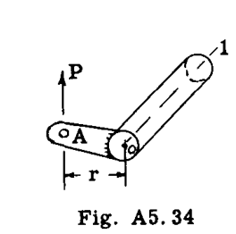

Fig. A5.34

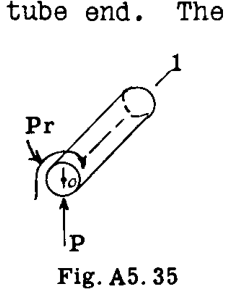

Fig. A5.35

## A5.11 翼の剪断力とモーメント (Shears and Moments on Wing)

第A4章のA4.5節およびA4.6節では、翼に働く空気力と、飛行中における飛行機全体の平衡について説明している。説明されているように、翼型上の分布空気力を、翼型の空気力学中心に作用する2つの合力（すなわち、揚力および抗力）と翼モーメントに置き換えるのが一般的である。翼の周囲の空気の流れは翼幅方向に均一ではないため、翼型力係数 $C_L$ 、 $C_D$ 、および $C_M$ は翼幅方向に沿って変化する。図 A5.36は、均一な翼幅方向の変化 $\bar{C}_L$ および $\bar{C}_D$ に対する、 $C_L$ および $C_D$ 力係数の代表的な翼幅方向の変化を示している。

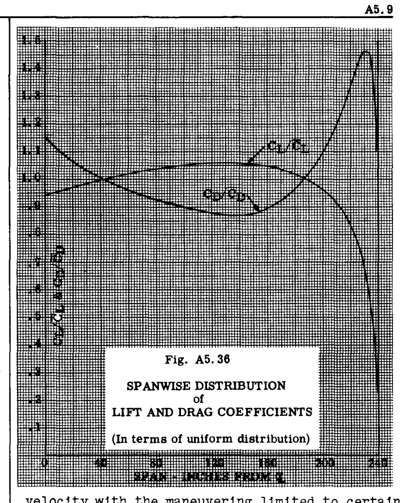

Fig. A5.36

特定のタイプの飛行機は、特定の任務または任務を遂行するように設計されており、その任務を遂行するためには、特定の最大飛行機速度が必要となり、操舵は特定の最大加速度に制限される。これらの制限加速度は、通常、飛行機のX、Y、Z軸を基準にして指定される。揚力および抗力の方向は迎角によって変化するため、構造解析においては、飛行機に対して相対的に方向が固定されているX、Y、Z軸を基準にしてすべての力を分解する方が簡単で便利である。

翼の応力解析における時間節約要素として、翼の剪断力とモーメントについて単位荷重解析を行うのが一般的である。任意の設計条件に対する翼の剪断力とモーメントは、単純な比例と加算によって得られる。例えば、以下のように仮定するのが一般的である：

1. 翼型の空気力学中心を通り、Z方向に働く任意の全単位荷重が翼に作用し、その翼幅方向の分布は $C_L$ （揚力係数）の分布に従うと仮定する。
2. (1)と同様の全荷重であるが、X方向に作用するもの。
3. 空気力学中心を通り、Z方向に働く全単位翼荷重を想定し、その翼幅方向の分布は $C_D$ （抗力係数）の分布に従うと仮定する。
4. (3)と同様であるが、X方向に作用するもの。
5. 単位全翼モーメントを想定し、その翼幅方向の分布は $C_{m_{a.c.}}$ （モーメント係数）の分布に従うと仮定する。

上記の単位荷重条件は、剛体としての飛行機の並進加速度の条件に対するものである。飛行および着陸の操舵において発生し得る飛行機の角加速度についても、単位荷重解析が行われる。

飛行機に作用する荷重の計算という主題は、構造の教科書でカバーするには大きすぎる。この主題は通常、学生が空気力学と構造の初期コースを修得した後、ほとんどの航空カリキュラムにおいて独立したコースでカバーされる。飛行機に作用する外力の計算において遭遇する問題のタイプを説明するために、翼と胴体に関する簡略化された問題が提示される。

## A5.12 1つの単位荷重条件に対する翼の剪断力とモーメントの計算例 (Example Problem of Calculating Wing Shears and Moments for One Unit Load Condition)

図 A5.37は片持ち翼のハーフウィング平面形状を示している。図 A5.38はステーション0における翼断面を示している。基準Y軸は40%コード線とされており、この特定の翼レイアウトでは直線となっている。

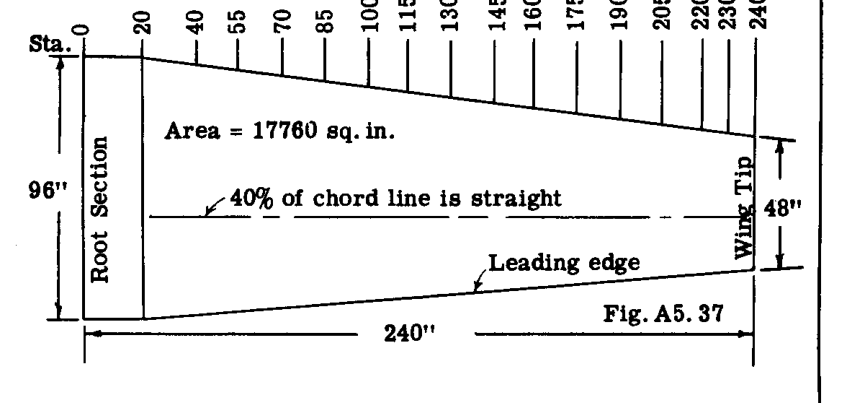

Fig. A5.37

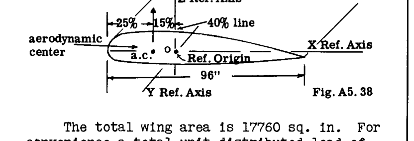

Fig. A5.38

総翼面積は $17760\text{ sq. in.}$ である。便宜上、総単位分布荷重 $17760\text{ lbs.}$ がハーフウィングに作用し、Z方向に上向きに、かつ翼型の空気力学中心を通って作用するものと仮定する。この荷重の翼幅方向の分布は、翼幅方向の $C_L$ 揚力係数分布に従う。この例では、簡単にするために、これを一定と仮定する。

表 A5.1は、翼端ステーション240から中心線ステーション0の間のいくつかのステーションについて、Z方向の翼剪断力 $V_z$ 、X軸周りの曲げモーメント $M_x$ 、またはY軸周りのモーメント $M_y$ を決定するための計算を表形式で示している。

表の第1列は選択されたステーションの番号を示している。第3列は、一様分布 $\bar{C}_L$ に対する揚力係数 $C_L$ の比、すなわち翼幅方向の変化を示している。この例では、この翼の翼幅方向の揚力係数分布に関する風洞試験や空気力学的な計算がないため、この比を1（一定）としている。実際の飛行機に関する問題では、図 A5.36に示されているような曲線が利用可能であり、表 A5.1の第3列に入れる値は、そのような曲線から読み取られる。第2列は、各ステーションにおける翼の弦長を示している。第4列は、各ステーションにおける翼幅1インチあたりのランニング荷重を示している。総単位荷重 $17760\text{ lb.}$ がハーフウィングに作用すると仮定され、翼面積が $17760\text{ sq. in.}$ であるため、任意のステーションにおける1インチあたりのランニング荷重は、そのステーションにおける翼の弦長に等しくなる。様々なステーション位置における剪断力とモーメントを求めるために、分布荷重は、ストリップ上の分布荷重に等しい集中荷重に分割され、この集中ストリップ荷重は、この分布ストリップ荷重の重心に作用するものとされる。第5、6、7列は、ストリップ荷重 $\Delta P_z$ を決定するための計算を示している。第8列は、その端部値が第4列に与えられている台形分布荷重の図心にある $\Delta P_z$ 荷重の位置を示している。これらの図心位置を決定するには、第A3章の表 A3.4を使用すると便利である。

ストリップ荷重 $\Delta P_z$ は、各翼型ストリップの空気力学中心（a.c.）を通って作用する。第13列および第14列は、a.c.から基準Y軸までの距離である $x$ アームを示している（図 A5.38参照）。第15列は各ストリップ荷重に対する $M_y$ モーメントを示し、第16列はステーション240から0に進むにつれてのストリップモーメントの累積に等しい、様々なステーションにおける $M_y$ モーメントを示している。

図 A5.39は、表 A5.1から取得したステーション(0)における結果を示している。

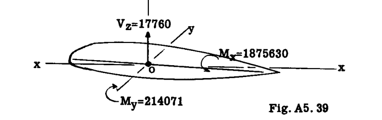

Fig. A5.39

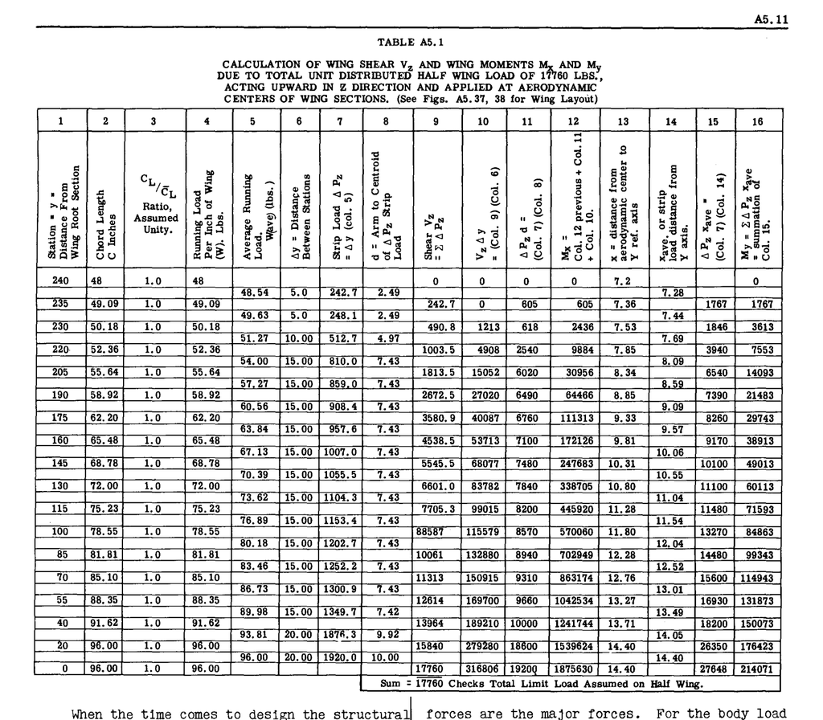

TABLE A5.1

これらの適用された剪断力やモーメントに耐えるための横断面の構造構成を設計する時が来たら、構造設計者は、例えば与えられた断面の剪断中心を通るような別のY軸に力を基準化したいと考えるかもしれない。別の座標系への力系のこの転送は、何ら困難を伴わない。

## 飛行機胴体の剪断力とモーメント (SHEARS AND MOMENTS ON AIRPLANE BODY)

### A5.13 はじめに (Introduction)

飛行機の胴体は、本質的に梁として機能し、特定の飛行または着陸条件においては、ねじり力またはねじり力を受ける可能性のある梁-柱としても機能する。したがって、飛行機の胴体を設計するには、飛行または着陸時に遭遇する可能性のある剪断、曲げ、ねじり、および軸力の完全な全体像が必要である。翼の荷重分析では、直接的な空気力が主要な力である。胴体の荷重分析では、直接的な空気圧は二次的なものであり、主要な力は、推進装置、翼、着陸装置、尾翼などの胴体に取り付けられたユニットからの荷重または反力の形で、集中した性質のものである。さらに、胴体は通常、荷重を支持する媒体として機能するため、内部機器、艤装、有効荷重などの重量の慣性力に対抗して、胴体に重要な力が発生する。

翼の場合と同様に、荷重分析の大部分は、胴体の構造解析をあまり考慮せずに行うことができる。飛行機胴体の荷重分析には大量の計算が含まれるため、本章での取り扱いは簡略化された性質のものでなければならず、主に、飛行機胴体の荷重分析の問題が一般的にどのようにアプローチされるかを学生に示すことを目的として提示されている。

### A5.14 設計条件と設計重量 (Design Conditions and Design Weights)

飛行機の胴体は、操縦条件と突風条件の両方について、指定された飛行条件からのすべての荷重に耐えるように設計されなければならない。空気の突風による加速度は飛行機の重量に反比例して変化するため、飛行条件については軽量荷重条件で胴体を解析またはチェックするのが一般的である。一般に、設計重量は政府機関によって指定される。ただし、着陸条件については、軽量荷重条件よりも重要であるため、通常の総重量が使用される。

胴体の設計において通常調査される一般的な設計条件は以下の通りである：

#### 飛行条件 (Flight Conditions)

- **H.A.A.** (High angle of attack) 高迎角
- **L.A.A.** (Low angle of attack) 低迎角
- **I.L.A.A.** (Inverted low angle of attack) 背面低迎角
- **I.H.A.A.** (Inverted high angle of attack) 背面高迎角

上記の条件は、一般に並進加速度のみを想定している。さらに、飛行機の重心の周りの特定の角加速度による力を考慮しなければならないと指定されることもある。胴体は通常、空気の突風やエンジン力などによって生じる可能性のある、対称および非対称の両方の特別な尾翼荷重に耐えることが要求される。また、翼上の非対称な空気荷重による力についても胴体をチェックする必要がある。

#### 着陸条件 (Landing Conditions)

一般に、胴体は以下の着陸条件について調査される。各条件の詳細な要件は、軍用機と民間機の両方の政府仕様書に記載されている。

##### 陸上機 (Landplanes)

- 水平着陸 (Level landing)
- 側方荷重を伴う水平着陸 (Level landing with side load)
- 3点着陸 (Three point landing)
- 地上スピンを伴う3点着陸 (Three point landing with ground loop)
- ノーズオーバーまたは転覆条件 (Nose over or turn over condition)
- アレスティング (Arresting)（通常は海軍の艦載機のみ）

##### 水上機または艇 (Seaplanes or Boats)

- 角加速度を伴うおよび伴わないステップ着陸 (Step landing with and without angular acceleration)
- 船首着陸 (Bow landing)
- 船尾着陸 (Stern landing)
- 2波着陸 (Two wave landing)
- ビーチング条件 (Beaching conditions)
- カタパルト射出条件 (Catapulting conditions)（海軍機）

##### 特別な条件または力 (Special Conditions or Forces)

- 飛行機の曳航 (Towing of airplane)
- 胴体与圧 (Body supercharging)

### A5.15 胴体の重量と重心分布 (Body Weight and Balance Distribution)

胴体とその内容物の自重による抵抗慣性力は、飛行機胴体の荷重分析において重要な役割を果たす。初期の空気力学的および一般的なレイアウトと配置が行われたとき、飛行機の完全な重量と重心の推定を行う必要がある。この推定は通常、飛行機ユニットの重量と分布の推定の経験を持つエンジニアリング部門の重量管理セクションのエンジニアによって行われる。レポート形式で提示されるこの推定は、すべての主要な飛行機ユニットまたは艤装、およびこれらの主要な飛行機組立品または艤装を構成する多くの副次的なユニットの重量と（例えば）位置を示す。この重量と重心のレポートは、飛行機胴体の荷重分析の重要な部分を形成する自重慣性荷重分析の基礎を形成する。この重量と重心の推定の使用については、後述の例題で説明する。

### A5.16 荷重分析。単位分析。 (Load Analysis. Unit Analysis.)

A5.14節に記載されているような多くの設計条件があるため、飛行機胴体の荷重分析における一般的な手順は、一連の単位分析に基礎を置くことである。その後の任意の特定の設計条件に対する荷重は、適切な乗数を乗じた単位結果の特定の組み合わせとして得られる。この単位アプローチ方法を説明する簡単な例題が以下に続く。

### A5.17 単位荷重条件による胴体の剪断力とモーメントの計算を説明する例題 (Example Problem Illustrating the Calculation of Shears and Moments on Fuselage Due to Unit Load Conditions)

図 A5.40およびA5.41は、この例題で使用される飛行機胴体のレイアウトを示している。これは実際の飛行機の胴体であり、前の例題で使用された翼は、この飛行機に付随していた翼である。

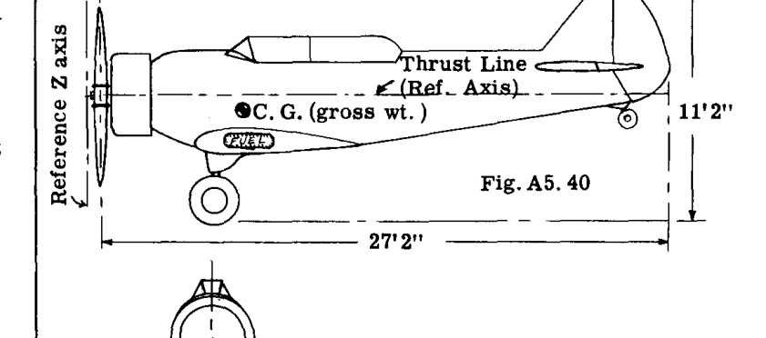

Fig. A5.40

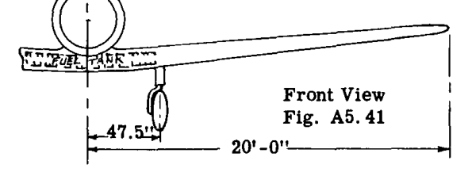

Fig. A5.41

表 A5.2は、飛行機全体の重量と重心の推定を示している。この表は通常、エンジニアリング部門の重量・重心セクションによって作成され、飛行機の荷重分析を行う前にこの情報を入手しておく必要がある。

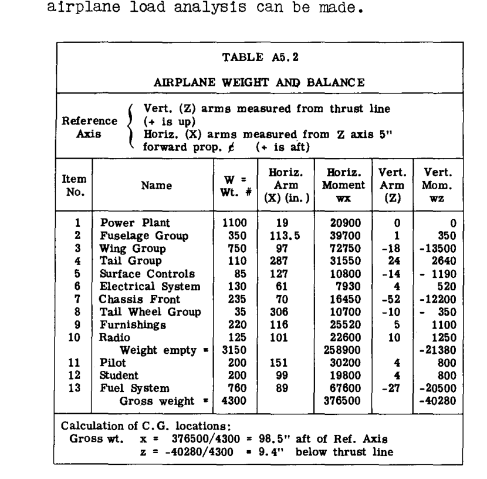

TABLE A5.2

### 解答 (SOLUTION):

#### 胴体項目の重量と重心 (WEIGHT AND BALANCE OF BODY ITEMS)

#### 重量分布 (WEIGHT DISTRIBUTION)

表 A5.3は、翼および前脚や燃料などの翼に取り付けられた項目を除き、胴体に取り付けられているか、または胴体内に搭載されているすべての項目の重量と重心の計算を示している。

自重慣性荷重による胴体上の真の剪断力とモーメントに極めて近い近似値を得るためには、表 A5.3に示されている様々な項目の重量を分配する必要がある。図 A5.42は、表 A5.3の重量項目の重心位置が（＋）記号で示された飛行機の側面図を示している。様々な設計条件において、重量慣性力の方向は変化するため、慣性力をX成分とZ成分に分解することが便利であり、一般的である。したがって、図 A5.43では、表 A5.3に示されている重量は、それらの（c.g.）位置を通ってZ方向に作用するものと仮定されている。示されている荷重は、胴体に沿った剪断力とモーメントの真の全体像を与えないため、これらの荷重は、実際の重量分布をシミュレートするような方法で分配されるべきである。ほとんどの重量および重心レポートでは、重量項目は表 A5.3に示されているものよりもかなり細かく分解されており、これにより重量分布がより明確になる。重量分布を行う者は、すべての艤装および機器の一般的な配置を示す飛行機の内部プロファイル図を研究すべきである。さらに、胴体の重量分布に影響を与える可能性のある、全体的な構造配置について研究すべきである。良好な重量分布の近似値を得るためには、プロセス全体にわたってかなりの常識が必要である。幸いなことに、推進装置、尾翼などの大きな自重荷重は明確に配置されているため、比較的小さな分配重量の分布における小さな誤差は、全体の剪断力とモーメントをそれほど変化させない。

妥当な精度を得るために、胴体は一連のステーションまたはセクションに分割される。図 A5.42において、選択されたセクションは、Z基準軸からの距離を表すステーションとして指定されている。一般的な問題は、図 A5.43に示されている集中荷重を、様々な胴体ステーション位置に作用する等価なシステムに分配することである。

明らかに、表 A5.3の重量項目が操縦士、学生、無線機などの集中荷重を表している場合、重量はこれらの隣接するステーションからの重量（c.g.）の距離に反比例して、隣接するステーション位置に分配することができる。しかし、そのc.g.位置が図 A5.43のステーション80と120の間に落ちる胴体構造（表 A5.3の項目2）のような重量項目については、350#の重量が胴体全体のものであるため、この重量を隣接する2つのステーションのみに分配することは明らかに誤りである。したがって、この350#の重量項目は、すべてのステーション位置に分配されるべきである。この分布における支配的な要件は、基準軸まわりの分配されたシステムのモーメントが、同じ軸まわりの元の重量のモーメントと等しくなければならないということである。図 A5.44は、350#の自重が、重量がZ方向に作用すると仮定して、様々なステーション位置にどのように分配されたかを示している。

表 A5.4は、表 A5.3の重量項目に対する、このステーション位置重量分布の結果を示している。各重量項目の反対側の水平行の値は、様々な胴体ステーションへの分布を示している。表 A5.4の下から3番目の水平行に示されている、各ステーション位置における各垂直列の重量の合計は、最終的なステーション位置重量を与える。これらの重量は、Z方向に作用する重量について図 A5.45に示されている。Z軸まわりの各総ステーション荷重のモーメントは、表 A5.4の下から2番目の水平行に示されている。この行のモーメントの合計は、表 A5.3の総 $Wx$ モーメント、すなわち $219700\text{ "\#}$ に等しくなければならない。このチェックは、表 A5.4の最後の垂直列の底部に示されている。

分配されたシステムはまた、図 A5.46に示されている元の重量システムと同じ合成c.g.位置を持つように、Z方向または垂直方向に分配されなければならない。図 A5.47は、図 A5.44に示されている分配された胴体重量システムが、このシステムのあるX軸まわりのモーメントが350#の元の胴体重量のモーメントに等しくなるように、様々なステーション位置において垂直方向にどのように分配されるかを示している。便宜上、これらの分配された胴体重量は、図 A5.48に示されているように、X軸にモーメントを加えたものに変換することができる。

表 A5.4は、様々なステーション位置における様々な項目の垂直方向の分布を示している。底部の水平行は、各ステーション位置における荷重のX軸まわりのモーメントを示しており、これは個々の荷重にそれらのZ距離を掛けたものに等しい。この水平行の値の合計は、表 A5.3の総 $Wz$ モーメントに等しくなければならない。このチェックは、最後の垂直列の底部に示されている。図 A5.49は、X方向の重量分布について表 A5.4に示されている結果を示している。

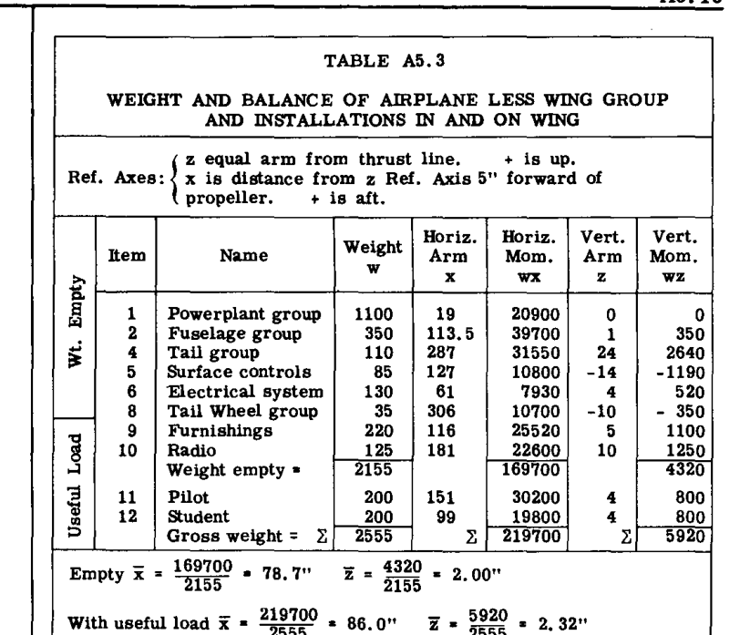

TABLE A5.3

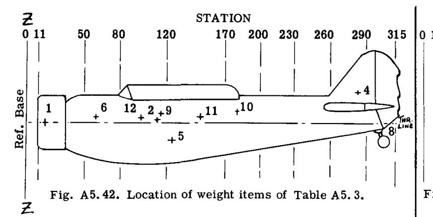

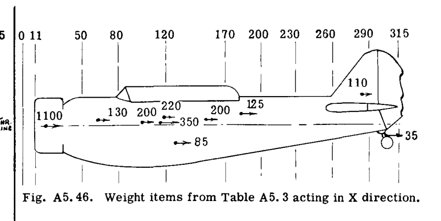

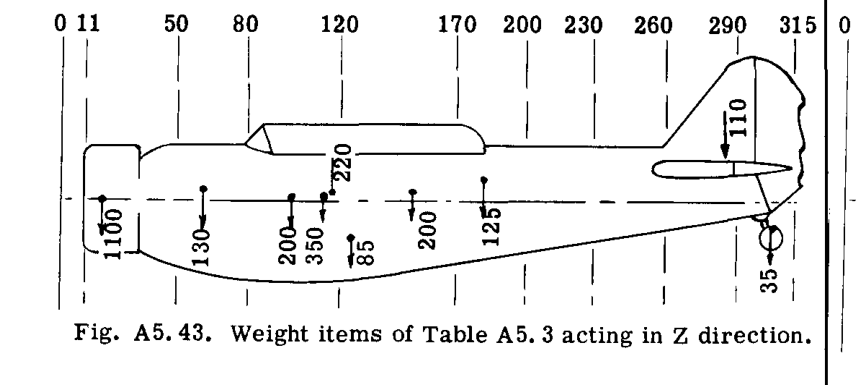

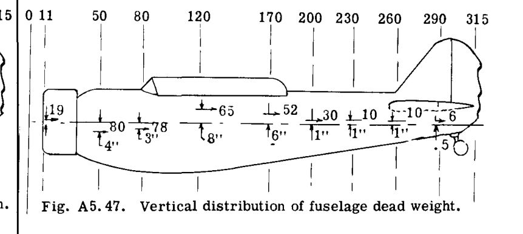

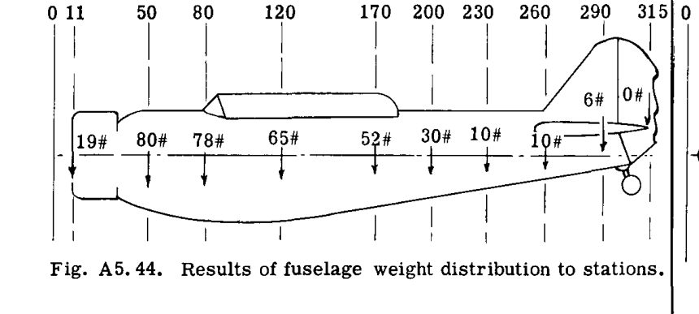

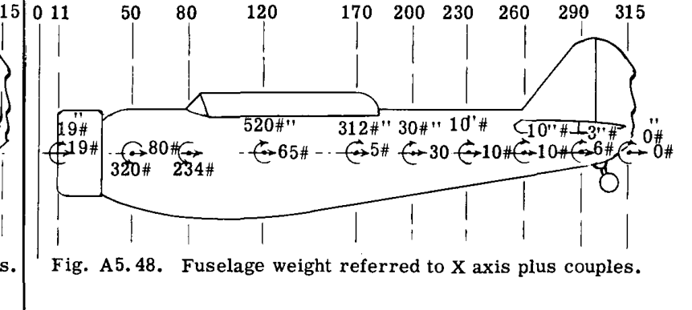

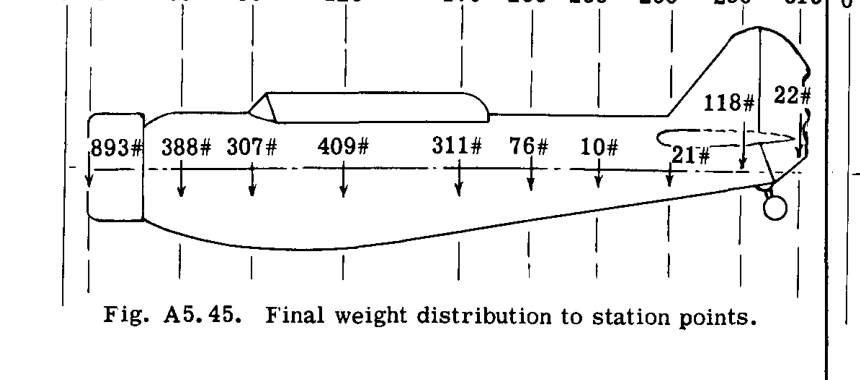

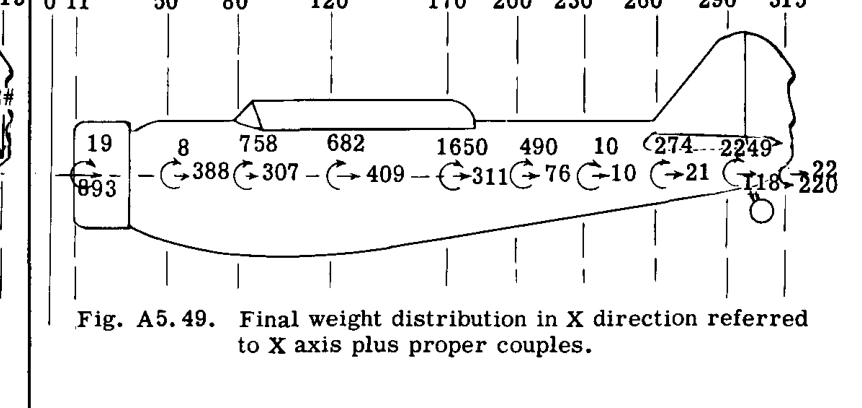

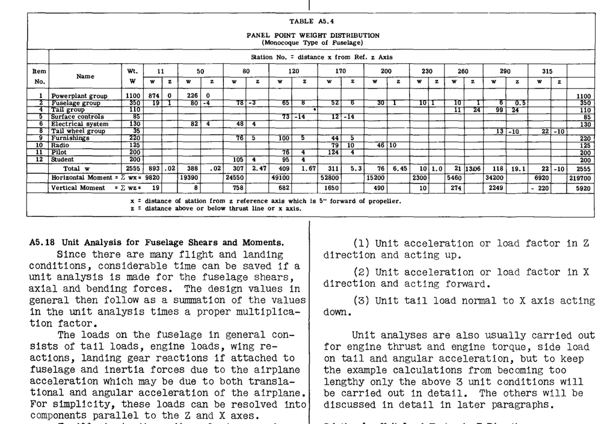

TABLE A5.4

### A5.18 胴体の剪断力とモーメントの単位分析 (Unit Analysis for Fuselage Shears and Moments)

多くの飛行および着陸条件があるため、胴体の剪断力、軸力、および曲げ力について単位分析を行っておけば、かなりの時間を節約することができる。一般に設計値は、単位分析における値の合計に適切な乗数を掛けたものとして得られる。

胴体上の荷重は、一般に、尾翼荷重、エンジン荷重、翼反力、胴体に取り付けられている場合は着陸装置反力、および飛行機の加速度による慣性力（飛行機の並進加速度と角加速度の両方によるもの）から構成される。簡単にするために、これらの荷重は、Z軸およびX軸に平行な成分に分解することができる。

単位分析の手順を説明するために、この例題の単位分析は以下の単位条件に対して行われる：

1. Z方向に作用し、上向きに働く単位加速度または荷重係数。
2. X方向に作用し、前向きに働く単位加速度または荷重係数。
3. X軸に垂直で、下向きに働く単位尾翼荷重。

単位分析は通常、エンジンの推力とエンジンのトルク、尾翼への側方荷重、および角加速度についても行われるが、計算が長くなりすぎるのを防ぐため、上記の3つの単位条件のみを詳細に実行する。その他については、以降の節で詳しく説明する。

#### Z方向の単位荷重係数の解答 (Solution for Unit Load Factor in Z Direction)

図 A5.50は、表 A5.4または図 A5.45から得られた、Z方向に作用する自重荷重を示している。翼は、図 A5.50に示されているように、ステーション73および116で胴体に取り付けられている。これらの点におけるフィッティングは、X方向のすべての抗力または反力が、ステーション73のフロントフィッティングで完全に受け止められるように設計されていると仮定する。

胴体を平衡状態に置くために、翼の反力が計算される：

$$\Sigma F_x = 0, \quad R_H + 0 = 0, \quad \text{したがって} \quad R_H = 0$$

$$\Sigma M_{\text{station } 0} = 219700 - 116 R_R - 73 R_F = 0 \quad
---\text{ (A)}$$

（注：219700は表 A5.3から）

$$\Sigma F_z = -2555 + R_F + R_R = 0 \quad ---\text{ (B)}$$

$R_F$ および $R_R$ について方程式(A)および(B)を解くと：

$$R_F = 1780 \text{ lb.}, \quad R_R = 775 \text{ lb.}$$

表 A5.5は、様々なステーション位置における胴体の剪断力と曲げモーメントの計算を示している。

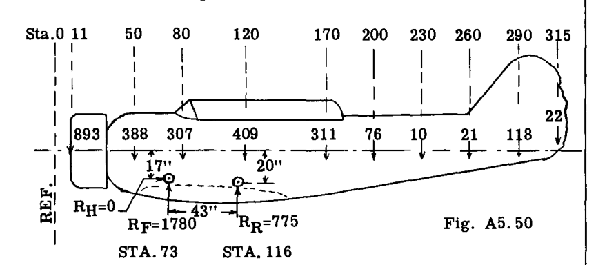

Fig. A5.50

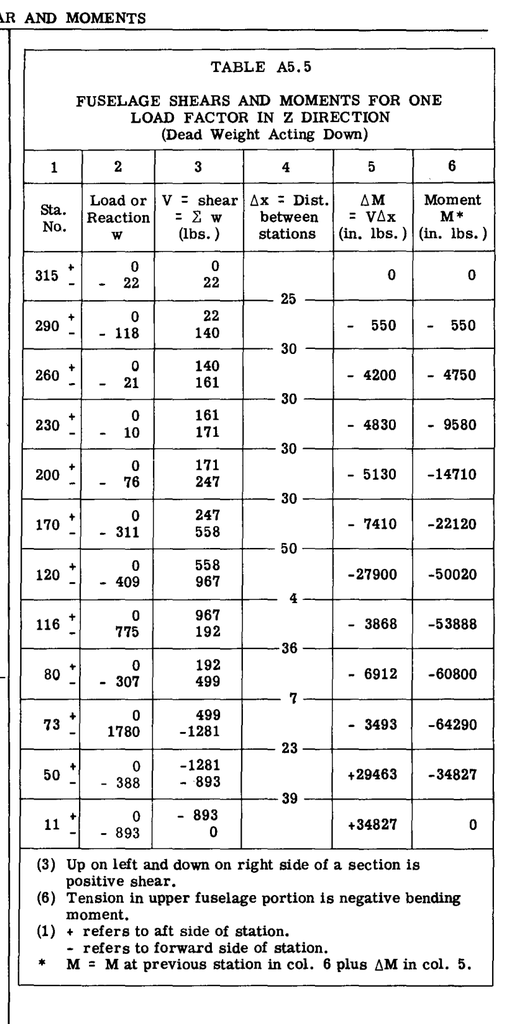

TABLE A5.5

#### X方向の単位荷重係数の解答 (Solution for Unit Load Factor in X Direction)

$$\Sigma F_x = 2555 - R_H = 0, \quad \text{したがって} \quad R_H = 2555
\text{ lb. (前向き)}$$

点(A)まわりのモーメントを取る：

$$\Sigma M_A = 2555 \times 17 + 5920 - 43 R_R = 0,$$

$$\text{したがって} \quad R_R = 1147.8 \text{ (上向き)}$$

（5920は表 A5.4からの偶力の和に等しい）

$$\Sigma F_z = 1147.8 - R_F = 0, \quad \text{したがって} \quad R_F =
1147.8 \text{ lb. (下向き)}$$

表 A5.6は、図 A5.51の荷重に対する剪断力、モーメント、および軸力の計算を示している。

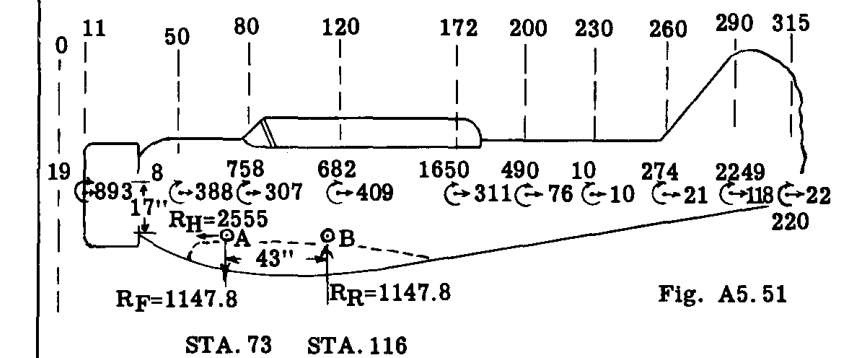

Fig. A5.51

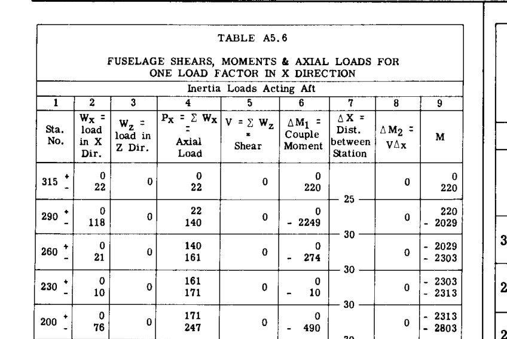

TABLE A5.6

#### 下向きに作用する単位水平尾翼荷重の解答 (Solution for Unit Horizontal Tail Load Acting Down)

胴体の剪断力とモーメントは、翼の取付点における釣り合い反力を伴う、Z方向に作用する尾翼上の $100\text{ lb.}$ の単位尾翼荷重に対して計算される。水平尾翼上の圧力中心はステーション277.5にある。図 A5.52は胴体の荷重を示している。(A)および(B)における翼反力を求めるために：

$$\Sigma M_A = 100 \times (277.5 - 73) - 43 R_R = 0, \quad
\text{したがって} \quad R_R = 475.6\# \text{ (上向き)}$$

$$\Sigma F_z = -100 + 475.6 - R_F = 0, \quad \text{したがって} \quad R_F =
375.6\# \text{ (下向き)}$$

表 A5.7は、様々なステーション位置における剪断力とモーメントの詳細な計算を示している。

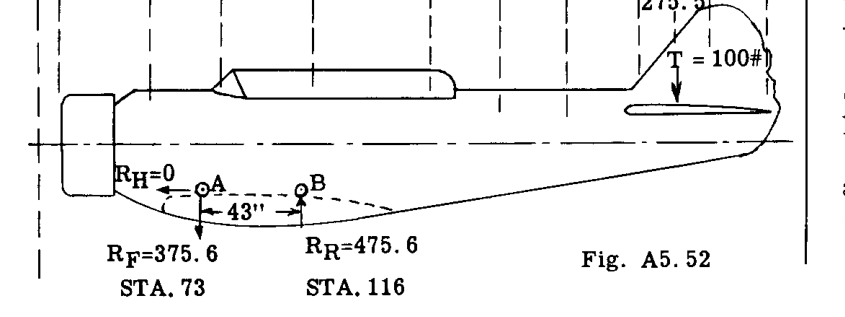

Fig. A5.52

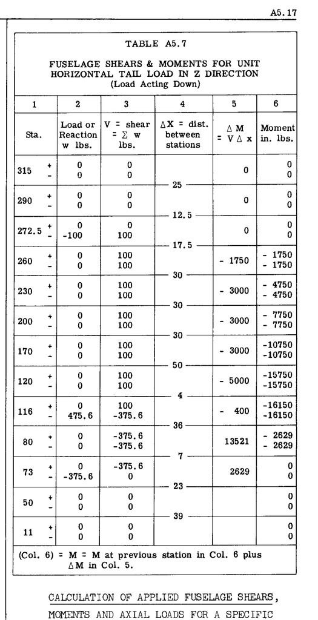

TABLE A5.7

### 特定の飛行条件に対する適用胴体剪断力、モーメント、および軸力の計算 (CALCULATION OF APPLIED FUSELAGE SHEARS, MOMENTS AND AXIAL LOADS FOR A SPECIFIC FLIGHT CONDITION)

表 A5.5、A5.6、およびA5.7の結果を使用すると、特定の飛行条件に対する適用剪断力とモーメントは、比例と加算によって得られる。説明のために、1つの飛行条件に対する適用値を示す。

したがって、Z方向とX方向の荷重係数および尾翼荷重が分かれば、示されているように表 A5.8を記入することができる。同様の方法で、他の飛行条件に対する値を求めることができる。唯一の違いは、適用される荷重が異なるため、新しい乗数のセットが必要になることである。

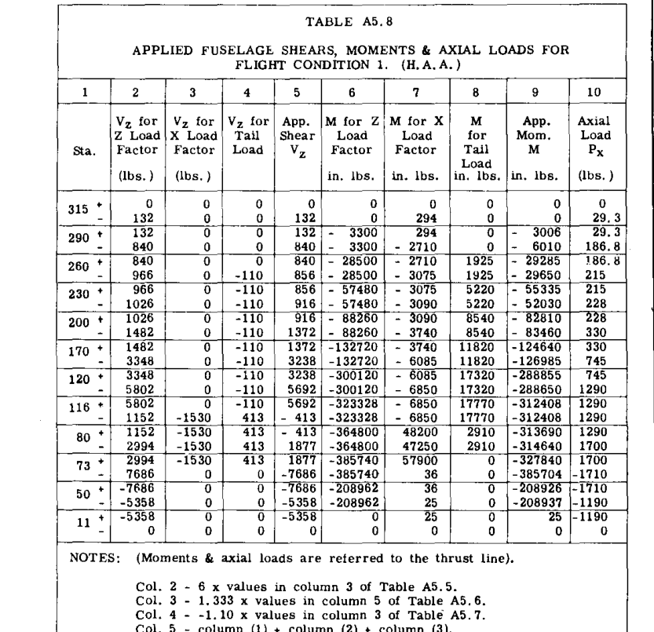

TABLE A5.8

### A5.19 着陸条件に対する胴体の剪断力とモーメントの例題 (Example of Fuselage Shears and Moments for Landing Conditions)

図 A5.53は、水平着陸条件における飛行機を示している。地面反力は、着陸装置の車輪の中心と飛行機の重心を通るものと仮定されている。垂直極限荷重係数が7のとき、胴体の剪断力、モーメント、および軸力が必要となる（総重量 = 4300#）。

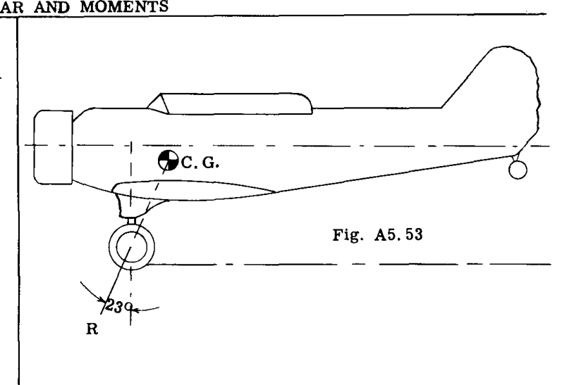

Fig. A5.53

### 解答 (SOLUTION):

地面反力 $R$ の垂直またはZ成分は、7つの荷重係数として指定されており、これは $7 \times 4300 = 30100\#$ に等しい。この半分が各車輪に作用している。

$R$ の水平またはX成分は、

$$30100 \tan 23^\circ = 0.425 \times 30100 = 12800\#$$

であり、後方に作用する。飛行機上の水平荷重係数は、

$$\frac{12800}{4300} = 2.98$$

に等しい。

地面反力 $R$ のこれらのXおよびZ成分に対する抵抗は、XおよびZ方向の飛行機の慣性力によって提供される。

表 A5.5およびA5.6は、それぞれZ方向およびX方向の1つの荷重係数による慣性荷重に対する胴体の剪断力、モーメント、および軸力を示している。したがって、この特定の着陸条件に対する胴体力を得るためには、これら2つの表の値を適切な係数で掛け合わせ、その結果を加算するだけでよい。

したがって、7の垂直荷重係数による胴体力は、表 A5.5の第3列の値に7を掛けたものが剪断力になり、第6列に7を掛けたものが曲げモーメントになる。

同様に、X方向の2.98の荷重係数による力は、表 A5.6の第4、5、および9列の値に $-2.98$ を掛けたものが、それぞれ軸力、剪断力、および曲げモーメントになる。

最終的な、または真の力は、これらの結果の代数和となる。

#### 角加速度を伴う着陸 (Landing with Angular Acceleration)

水平着陸条件において、地面反力の水平成分が垂直成分の特定の割合でなければならないと指定されることがあり、これにより図 A5.53の地面反力 $R$ の作用線が飛行機の重心を通らなくなり、飛行機に外部ピッチングモーメントが発生する。このモーメントは通常、重心まわりの不平衡モーメントによって生じる角加速度による慣性力によって釣り合わされる。この外部モーメントによる胴体上の剪断力とモーメントは、A5.20節で説明されているように求めることができる。

### A5.20 角加速度による慣性荷重 (Inertia Loads Due to Angular Acceleration)

一部の飛行条件では、飛行機が並進加速度に加えて角加速度を受けなければならないと指定されることがある。この飛行機の角加速度は慣性力を生み出し、飛行機を静的平衡の物体として扱う場合には、これを計算しなければならない。場合によっては、尾翼への突風による尾翼荷重が指定され、これが飛行機の重心まわりのモーメントを生み出し、飛行機の角加速度を引き起こす。特定の着陸条件では、地面の力が飛行機の重心を通らないため、重心まわりのモーメントが発生し、応力解析の目的で、これが慣性力によって釣り合わされる。

#### 飛行機の慣性モーメント (Moment of Inertia of Airplane)

飛行機の重心軸まわりの慣性モーメントの計算については、第A3章のpage A3.5で説明されている。詳細な計算例は、第A3章の表6Aに詳しく示されている。基準軸まわりの飛行機の慣性モーメントの一般式は以下の通りである：

$$I_y = \Sigma w x^2 + \Sigma w z^2 + \Sigma \Delta I_y$$

$$I_x = \Sigma w y^2 + \Sigma w z^2 + \Sigma \Delta I_x$$

$$I_z = \Sigma w y^2 + \Sigma w x^2 + \Sigma \Delta I_z$$

上記の方程式の最後の項は、基準軸に平行なそれ自体の重心軸まわりの各重量項目の慣性モーメントを表している。

### A5.21 単位 $100,000\text{ in. lbs.}$ ピッチングモーメントによる慣性荷重の解答 (Solution for Inertia Loads Due to Unit 100,000 In. Lbs. Pitching Moment)

飛行機が重心まわりの不平衡モーメントを受けるときの、釣り合い慣性荷重を決定する一般的な手順を説明するために、単位 $100,000\text{ in. lb.}$ モーメントに対する分析を行う。表 A5.9に必要な計算が示されている。

動力学から：

$$\text{ピッチング角加速度 } a = \frac{M_y}{I_y} \quad (\text{rad/sec}^2)$$

ここで、 - $M_y$ = 飛行機の重心まわりの不平衡外部ピッチングモーメント。 - $I_y$ = 飛行機の重心まわりのピッチング慣性モーメント = $\Sigma w r^2$

角加速度 $a$ による質量 $w/g$ の接線慣性力 $F$ は、

$$F = \frac{w}{g} r a, \quad \text{しかし} \quad a = \frac{M_y}{I_y} g$$

したがって、

$$F = \frac{M_y}{I_y} w r, \quad \text{ここで } r \text{ は重量 } w \text{
から飛行機の重心までの距離である。}$$

慣性力 $F$ を $F_x$ と $F_z$ の2つの成分に分解して扱うのが便利である。したがって、

$$F_z = \frac{M_y}{I_y} w x_c \quad ---\text{ (1)}$$

$$F_x = \frac{M_y}{I_y} w z_c \quad ---\text{ (2)}$$

表 A5.9から、 $I_y = 16097600$

$M_y$ は $100,000$ と仮定された。

したがって、

$$F_z = \frac{100000}{16097600} w x_c = .00621 w x_c$$

$$F_x = .00621 w z_c$$

ここで、 $z_c$ および $x_c$ は、重量 $w$ から飛行機の重心までの $z$ および $x$ の距離である。

表 A5.9における慣性抵抗荷重は近似値にすぎないことを認識すべきである。なぜなら、慣性モーメントの計算において、推進装置や翼などの大きな項目の重心慣性モーメントを無視しているからである。この例は、角加速度による慣性抵抗荷重を決定する一般的な手順を説明することのみを目的としている。一般にヨーイングおよびローリングモーメントと呼ばれる、Z軸およびX軸まわりの不平衡外部モーメントを考慮する場合にも、同じ一般的な手順に従うことができる。

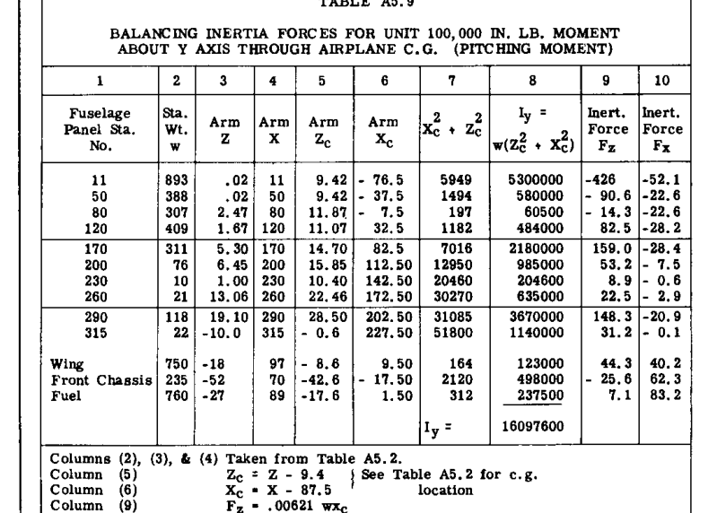

TABLE A5.9